# Problem Set 1

Due April 11th at 5:30pm -- at the start of the class so we can discuss the solutions in class.

### Before You Start

Make sure to at least take a basic tutorial in the IPython notebook, otherwise you'll be totally lost. For this problem set, you should download flights.csv.bz2 and weather.csv.bz2 datasets from Canvas (files-data). Rename the notebook to LASTNAME_FIRSTNAME-PS1.ipynb.

When done, please submit

1. the notebook itself
2. the rendered html or pdf of it.

## About the Problem Set:

This problem set is rather similar to ones used for R, dplyr, and flights data. Just we use python and pandas.

In this problem set you will perform a basic exploratory analysis on an example dataset, bringing to bear all of your new skills in data manipulation and visualization. You will be required to submit well commented python code, documenting all code used in this problem set, along with a write up answering all questions below. Use figures as appropriate to support your answers, and when required by the problem.

## Preliminaries

You should also make sure the following libraries load correctly (click on the box below and hit Ctrl-Enter)

```python
#IPython is what you are using now to run the notebook
import IPython
print( "IPython version:      %6.6s (need at least 1.0)" % IPython.__version__)

# Numpy is a library for working with Arrays
import numpy as np
print( "Numpy version:        %6.6s (need at least 1.7.1)" % np.__version__)

# SciPy implements many different numerical algorithms
import scipy as sp
print( "SciPy version:        %6.6s (need at least 0.12.0)" % sp.__version__)

# Pandas makes working with data tables easier
import pandas as pd
print( "Pandas version:       %6.6s (need at least 0.11.0)" % pd.__version__)

# Module for plotting
import matplotlib
import matplotlib.pyplot as plt
print( "Mapltolib version:    %6.6s (need at least 1.2.1)" %
       matplotlib.__version__)
%matplotlib inline
# necessary for in-line graphics

# SciKit Learn implements several Machine Learning algorithms
import sklearn
print( "Scikit-Learn version: %6.6s (need at least 0.13.1)" % sklearn.__version__)
```

```
IPython version:       6.1.0 (need at least 1.0)
Numpy version:        1.13.1 (need at least 1.7.1)
SciPy version:        0.19.1 (need at least 0.12.0)
Pandas version:       0.20.3 (need at least 0.11.0)
Mapltolib version:     2.0.2 (need at least 1.2.1)
Scikit-Learn version: 0.19.0 (need at least 0.13.1)
```

```python
import pylab as pl
from pylab import *
from scipy import *
from pylab import rcParams
import statsmodels.formula.api as smf
```

```python
## Let's read the data and print some summary information
## adjust the path for your file system!
flights_df= pd.read_csv('flights.csv.bz2')
```

```python
print (flights_df.shape)
print (flights_df.columns)
print (flights_df.dtypes)
```

```
(336776, 17)
Index(['Unnamed: 0', 'year', 'month', 'day', 'dep_time', 'dep_delay',
       'arr_time', 'arr_delay', 'carrier', 'tailnum', 'flight', 'origin',
       'dest', 'air_time', 'distance', 'hour', 'minute'],
      dtype='object')
Unnamed: 0      int64
year            int64
month           int64
day             int64
dep_time      float64
dep_delay     float64
arr_time      float64
arr_delay     float64
carrier        object
tailnum        object
flight          int64
origin         object
dest           object
air_time      float64
distance        int64
hour          float64
minute        float64
dtype: object
```

```python
flights_df.dest.unique()
flights_df.head(10)
```

|  | Unnamed: 0 | year | month | day | dep_time | dep_delay | arr_time | arr_delay | carrier | tailnum | flight | origin | dest | air_time | distance | hour | minute |
| --- | --- | --- | --- | --- | --- | --- | --- | --- | --- | --- | --- | --- | --- | --- | --- | --- | --- |
| 0 | 1 | 2013 | 1 | 1 | 517.0 | 2.0 | 830.0 | 11.0 | UA | N14228 | 1545 | EWR | IAH | 227.0 | 1400 | 5.0 | 17.0 |
| 1 | 2 | 2013 | 1 | 1 | 533.0 | 4.0 | 850.0 | 20.0 | UA | N24211 | 1714 | LGA | IAH | 227.0 | 1416 | 5.0 | 33.0 |
| 2 | 3 | 2013 | 1 | 1 | 542.0 | 2.0 | 923.0 | 33.0 | AA | N619AA | 1141 | JFK | MIA | 160.0 | 1089 | 5.0 | 42.0 |
| 3 | 4 | 2013 | 1 | 1 | 544.0 | -1.0 | 1004.0 | -18.0 | B6 | N804JB | 725 | JFK | BQN | 183.0 | 1576 | 5.0 | 44.0 |
| 4 | 5 | 2013 | 1 | 1 | 554.0 | -6.0 | 812.0 | -25.0 | DL | N668DN | 461 | LGA | ATL | 116.0 | 762 | 5.0 | 54.0 |
| 5 | 6 | 2013 | 1 | 1 | 554.0 | -4.0 | 740.0 | 12.0 | UA | N39463 | 1696 | EWR | ORD | 150.0 | 719 | 5.0 | 54.0 |
| 6 | 7 | 2013 | 1 | 1 | 555.0 | -5.0 | 913.0 | 19.0 | B6 | N516JB | 507 | EWR | FLL | 158.0 | 1065 | 5.0 | 55.0 |
| 7 | 8 | 2013 | 1 | 1 | 557.0 | -3.0 | 709.0 | -14.0 | EV | N829AS | 5708 | LGA | IAD | 53.0 | 229 | 5.0 | 57.0 |
| 8 | 9 | 2013 | 1 | 1 | 557.0 | -3.0 | 838.0 | -8.0 | B6 | N593JB | 79 | JFK | MCO | 140.0 | 944 | 5.0 | 57.0 |
| 9 | 10 | 2013 | 1 | 1 | 558.0 | -2.0 | 753.0 | 8.0 | AA | N3ALAA | 301 | LGA | ORD | 138.0 | 733 | 5.0 | 58.0 |

## Some Tips

- This assignment involves extensive Data frame splitting and aggregation. You should look into the details of the methods groupby, transform, sum, count, mean etc
- Many of the tasks in the assignment can be done either through the Pandas Data Frame or by converting the data frames to Series. Many of the methods in the numpy are applicable to Series only. When stuck, try to explore the type of object (Pandas Data Frame or Numpy Series) you are dealing with.

## Question 1

Let’s explore flights from NYC to Seattle. Use the flights dataset to answer the following questions.

(a) How many flights were there from NYC airports to Seattle in 2013?

```python
flights_sea = flights_df[((flights_df.origin == 'JFK') | (flights_df.origin == 'EWR') | (flights_df.origin == 'LGA')) & (flights_df.dest == 'SEA')]
len(flights_sea)
```

```
3923
```

The total number of flights from New York airports to Seattle is 3923 in the year 2013.

(b) How many airlines fly from NYC to Seattle?

```python
print(flights_sea.groupby(['dest','carrier']).size())
len(flights_sea.groupby(['dest','carrier']).size())
```

```
dest  carrier
SEA   AA          365
      AS          714
      B6          514
      DL         1213
      UA         1117
dtype: int64
```

```
5
```

Total number of airlines that fly from NYC to Seattle is 5.

(c) How many unique air planes fly from NYC to Seattle?

```python
len(flights_sea.tailnum.unique())
```

```
936
```

Total number of airplanes from NYC to Seattle are 936.

(d) What is the average arrival delay for flights from NC to Seattle?

```python
flights_sea.arr_delay.mean()
```

```
-1.0990990990990992
```

Average arrival delay for flights from NYC to Seattle is -1.0990 approximately which means flights are actually arrival before time on average (specifically by 1.099 mins early).

(e) What proportion of flights to Seattle come from each NYC airport?

```python
flights_tot = pd.DataFrame(flights_sea.groupby(['dest','origin']).size()/len(flights_sea) * 100)
flights_tot.reset_index(level=0,inplace=True)
flights_tot.reset_index(level=0,inplace=True)
flights_tot.columns = ['Origin', 'Destination','Proportion (%)']

flights_tot
```

|  | Origin | Destination | Proportion (%) |
| --- | --- | --- | --- |
| 0 | EWR | SEA | 46.673464 |
| 1 | JFK | SEA | 53.326536 |

Approx. 46% of flights come from EWR, 53% of flights come from JFK and 0% from LGA.

## Question 2

Flights are often delayed. Consider the following questions exploring delay patterns.

(a) Which date has the largest average departure delay? Which date has the largest average arrival delay?

```python
flights_df['date'] = flights_df['year'].astype(str) + '/' + flights_df['month'].astype(str) + '/' + flights_df['day'].astype(str)

flights_df_agg = pd.DataFrame(flights_df.groupby('date').mean())
flights_df_agg.reset_index(level=0,inplace=True)

max_avg_arr_delay = max(flights_df_agg['arr_delay'])
max_avg_dep_delay = max(flights_df_agg['dep_delay'])

print("Largest arrival delay was on date:", flights_df_agg.loc[flights_df_agg['arr_delay'] == max_avg_arr_delay,'date'].item(),"with Arrival Delay:",max_avg_arr_delay)

print("Largest departure delay was on date:", flights_df_agg.loc[flights_df_agg['dep_delay'] == max_avg_dep_delay,'date'].item(),"with Departure Delay:", max_avg_dep_delay)
```

```
Largest arrival delay was on date: 2013/3/8 with Arrival Delay: 85.8621553885
Largest departure delay was on date: 2013/3/8 with Departure Delay: 83.5369211514
```

Maximum arrival and departure delay is on the same date: 2013/3/8 with average arrival delay of 85.86 and departure delay of 83.53.

(b) What was the worst day to fly out of NYC in 2013 if you dislike delayed flights?

```python
flights_df_agg['total_delay'] = (flights_df_agg['arr_delay'] + flights_df_agg['dep_delay'])/2
s = max(flights_df_agg['total_delay'])

print(flights_df_agg.loc[flights_df_agg['total_delay'] == s,'date'].item(),": date has the maximum average total delay:", s)
print(flights_df_agg.loc[flights_df_agg['dep_delay'] == max_avg_dep_delay,'date'].item(),": date has the maximum departure delay:", max_avg_dep_delay)

dep_delay= flights_df[flights_df['dep_delay']>0]
dep_delay = pd.DataFrame(dep_delay.groupby('date').count())
dep_delay.reset_index(level=0,inplace=True)
print(dep_delay.loc[dep_delay['Unnamed: 0'] == max(dep_delay['Unnamed: 0']),'date'].item(),": date with most number of delayed flights in a day -", max(dep_delay['Unnamed: 0']))

print(flights_df.loc[flights_df['dep_delay'] == max(flights_df['dep_delay']),'date'].item(),": date has maximum delay in departure of a flight, with delay of",max(flights_df['dep_delay']))
```

```
2013/3/8 : date has the maximum average total delay: 84.69953827
2013/3/8 : date has the maximum departure delay: 83.5369211514
2013/12/23 : date with most number of delayed flights in a day - 674
2013/1/9 : date has maximum delay in departure of a flight, with delay of 1301.0
```

Worst day to fly out of NYC in 2013 if you disliked delayed flights would depend on, what someone considered as an inconvenience:

- total average delay (arrival + departure)
- maximum departure delay
- most number of delayed flights
- maximum departure delay of a flight

(c) Are there any seasonal patterns in departure delays for flights from NYC?

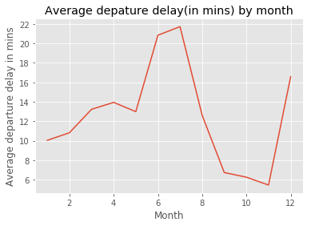

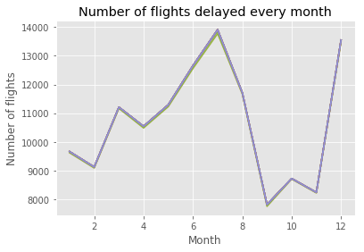

```python
plt.style.use('ggplot')

plt.plot(flights_df.groupby('month')['dep_delay'].mean())
plt.xlabel('Month')
plt.ylabel('Average departure delay in mins')
plt.title('Average depature delay(in mins) by month')
plt.show()

dep_delay = flights_df[flights_df['dep_delay'] > 0]
plt.plot(dep_delay.groupby('month').count())
plt.xlabel('Month')
plt.ylabel('Number of flights')
plt.title('Number of flights delayed every month')
plt.show()
```

(d) On average, how do departure delays vary over the course of a day?

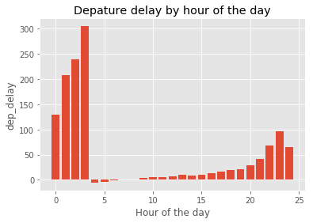

```
Number of flights by hour of the day: hour
0.0       881
1.0       223
2.0        64
3.0        11
4.0       305
5.0      7246
6.0     22699
7.0     21461
8.0     26424
9.0     18871
10.0    16076
11.0    16762
12.0    16071
13.0    16890
14.0    20480
15.0    22840
16.0    22336
17.0    22144
18.0    21549
19.0    19940
20.0    16160
21.0    10960
22.0     5483
23.0     2616
24.0       29
Name: flight, dtype: int64
```

```python
hour_dep_delay = pd.Series(flights_df.groupby('hour')['dep_delay'].mean())
hour_dep_delay[0:]

plt.bar(hour_dep_delay.index,hour_dep_delay)
xlabel('Hour of the day')
ylabel('dep_delay')
title('Depature delay by hour of the day')
plt.show()

print("Number of flights by hour of the day:",pd.Series(flights_df.groupby('hour')['flight'].count()))
```

As it can be seen from the plot, the average departure delay is highest during the night time which could be due to lower visibility during these hours of the day and hence, it decreases during the day time. Additionally, the number of flights during these hours is lesser which kind of help cater for these higher departure delays.

## Question 3

Which flight departing NYC in 2013 flew the fastest?

```python
flights_df['Speed'] = flights_df['distance'] / (flights_df['air_time']/60)
x = ['year','month','day','dep_time','dep_delay','carrier','tailnum','flight','origin','dest','air_time','Speed']
flights_df.sort_values('Speed', ascending = False)[x].head(1)
```

|  | year | month | day | dep_time | dep_delay | carrier | tailnum | flight | origin | dest | air_time | Speed |
| --- | --- | --- | --- | --- | --- | --- | --- | --- | --- | --- | --- | --- |
| 216447 | 2013 | 5 | 25 | 1709.0 | 9.0 | DL | N666DN | 1499 | LGA | ATL | 65.0 | 703.384615 |

Flight 1499 with tailnumber N666DN from La Guardia airport to Atlanta airport by the carrier DL, flew the fastest in 2013 with an average speed of 703 miles per hour.

## Question 4

Which flights (i.e. carrier + flight + dest) happen every day? Where do they fly to?

```python
flights_df['flight_details'] = flights_df['carrier'].astype(str) + ' ' + flights_df['flight'].astype(str) + ' ' + flights_df['dest'].astype(str)
flights_df.head()

flight_everyday = flights_df.groupby(['flight_details','date']).count()
flight_everyday.reset_index(level=0,inplace=True)
flight_everyday.reset_index(level=0, inplace=True)
flight_everyday.rename(columns={'Unnamed: 0':'count'}, inplace = True)


flight_everyday = flight_everyday.groupby('flight_details').count().sort_values('count', ascending = False)
flight_everyday.reset_index(level=0, inplace=True)

flights = flight_everyday[flight_everyday['count'] == 365]['flight_details']
print (flights)

dest = []

for i in flights.astype(str):
    dest.append(i[len(i)-3:])
    dests = set(dest)
print (dests)
```

```
0       UA 15 HNL
1      B6 371 FLL
2      AA 181 LAX
3      B6 219 CLT
4      AA 119 LAX
5      B6 703 SJU
6     DL 2391 TPA
7     AA 1357 SJU
8     EV 5712 IAD
9      VX 251 LAS
10    AA 1611 MIA
11     VX 413 LAX
12    DL 2159 MCO
13     B6 431 SRQ
14     VX 407 LAX
15      AA 59 SFO
16    B6 1783 MCO
17     B6 359 BUR
Name: flight_details, dtype: object
{'LAS', 'HNL', 'SJU', 'IAD', 'MIA', 'SFO', 'TPA', 'MCO', 'CLT', 'LAX', 'BUR', 'FLL', 'SRQ'}
```

There are total 18 flights that happen everyday:

1. UA 15 HNL
2. B6 371 FLL
3. AA 181 LAX
4. B6 219 CLT
5. AA 119 LAX
6. B6 703 SJU
7. DL 2391 TPA
8. AA 1357 SJU
9. EV 5712 IAD
10. VX 251 LAS
11. AA 1611 MIA
12. VX 413 LAX
13. DL 2159 MCO
14. B6 431 SRQ
15. VX 407 LAX
16. AA 59 SFO
17. B6 1783 MCO
18. B6 359 BUR

They fly to following airports -

- 'TPA': Tampa International Airport
- 'LAX': Los Angeles International Airport
- 'HNL': Honolulu International Airport
- 'CLT': Charlotte Douglas International Airport (NC)
- 'IAD': Washington Dulles International Airport (VI)
- 'SJU': San Juan Airport Hotel (Puerto Rico)
- 'LAS': McCarran International Airport (CA)
- 'MIA': Miami International Airport (FL)
- 'BUR': Bob Hope Airport (CA)
- 'MCO': Orlando International Airport (FL)
- 'SRQ': Sarasota–Bradenton International Airport (FL)
- 'SFO': San Francisco International Airport (CA)
- 'FLL': Fort Lauderdale–Hollywood International Airport (FL)

## Question 5

Develop one research question you can address using the nycflights2013 dataset. Provide two visualizations to support your exploration of this question. Discuss what you find.

#### Research Question: Which carriers from NYC were the best performers in year 2013 in terms of delays and which carrier would you select for flying from NYC?

```
   carrier  dep_delay
12      US   3.782418
8       HA   4.900585
2       AS   5.804775
1       AA   8.586016
4       DL   9.264505
9       MQ  10.552041
11      UA  12.106073
10      OO  12.586207
13      VX  12.869421
3       B6  13.022522
0       9E  16.725769
14      WN  17.711744
7       FL  18.726075
15      YV  18.996330
```

[output cut: 21 more lines]

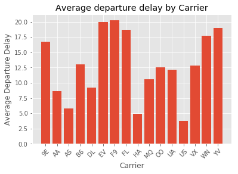

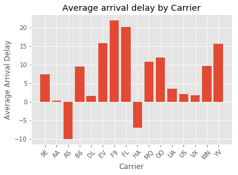

```python
flights_df_agg = pd.DataFrame(flights_df.groupby('carrier').mean())
flights_df_agg.reset_index(level=0,inplace=True)
flights_df_agg = flights_df_agg.sort_values('dep_delay')
print(pd.DataFrame(flights_df_agg, columns=['carrier','dep_delay']))

print("\n")
flights_df_agg = flights_df_agg.sort_values('arr_delay')
print(pd.DataFrame(flights_df_agg, columns=['carrier','arr_delay']))

d = pd.DataFrame(flights_df_agg.groupby('carrier').mean())

x = list(range(0,len(d.index.values)))
xTicks = list(d.index.values)
y = list(d['dep_delay'].values)
pl.xticks(x, xTicks)
pl.xticks(range(len(d.index.values)), xTicks, rotation=45)
pl.bar(x,y)
xlabel("Carrier")
ylabel("Average Departure Delay")
title("Average departure delay by Carrier")
pl.show()

x = list(range(0,len(d.index.values)))
xTicks = list(d.index.values)
y = list(d['arr_delay'].values)
pl.xticks(x, xTicks)
pl.xticks(range(len(d.index.values)), xTicks, rotation=45)
pl.bar(x,y)
xlabel("Carrier")
ylabel("Average Arrival Delay")
title("Average arrival delay by Carrier")
pl.show()
```

```
         avg_delay
carrier
AS       -2.042837
HA       -1.007310
US        2.976576
AA        4.502259
DL        5.482873
VX        7.389398
UA        7.890995
MQ       10.715892
B6       11.271622
9E       12.227549
OO       12.258621
WN       13.718406
YV       17.328440
EV       17.943901
FL       19.478193
F9       21.074047
```

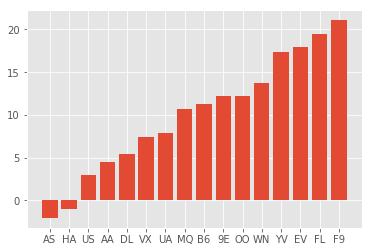

```python
flights_df['avg_delay'] = flights_df[['dep_delay','arr_delay']].mean(axis=1)
h = pd.DataFrame(flights_df.groupby('carrier')['avg_delay'].mean())
e = h.sort_values('avg_delay')
print(e)


x = list(range(0,len(e.index.values)))
xTicks = list(e.index.values)
y = list(e['avg_delay'].values)
pl.xticks(x,xTicks)
pl.xticks(range(len(e.index.values)),xTicks)
pl.bar(x,y)
pl.show()
```

```
  carrier  Unnamed: 0
0      OO           9
1      HA          69
2      AS         226
3      YV         233
4      F9         341
5      FL        1654
6      VX        2225
7      US        4775
8      WN        6558
9      9E        7063
```

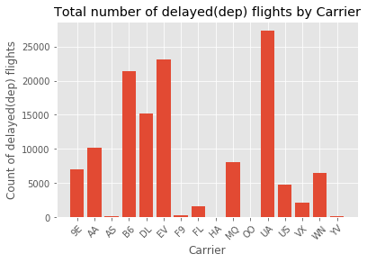

```python
dep_delay = flights_df[flights_df['dep_delay'] > 0]
d = pd.DataFrame(dep_delay.groupby('carrier').count())

f = pd.DataFrame(d.sort_values('Unnamed: 0'))
f.reset_index(level=0,inplace=True)
print(pd.DataFrame(f,columns=['carrier','Unnamed: 0']).head(10))

x = list(range(0,len(d.index.values)))
xTicks = list(d.index.values)
y = list(d['Unnamed: 0'].values)
pl.xticks(x, xTicks)
pl.xticks(range(len(d.index.values)), xTicks, rotation=45)
pl.bar(x,y)
xlabel("Carrier")
ylabel("Count of delayed(dep) flights")
title("Total number of delayed(dep) flights by Carrier")
pl.show()
```

Here is the summary of how the carrier are performing in the year 2013 for the flights travelling from NYC airports.

The top 6 carriers with the minimum departure delay are:

- US - 3.782418
- HA - 4.900585
- AS - 5.804775
- AA - 8.586016
- DL - 9.264505
- MQ - 10.552041

If someone doesn't like departure delays they can pick the 'US' carrier as they have the least departure delay (3.78 approx.).

Similarly, the top 6 carriers with minimum arrival delay are:

- AS -9.930889
- HA -6.915205
- AA 0.364291
- DL 1.644341
- VX 1.764464
- US 2.129595

If someone doesn't like arrival delays they can pick the 'AS' carrier as they have the least arrival delay (-9.93 approx.) which mean they arrive early.

Additionally, looks like flights by carrier 'UA' have a bad reputation for having departure delays. Hence, if you do not like delayed flights then advise would be to avoid 'UA' carrier flights.

Based on the analysis above, carrier 'AS' seems to be performing fairly well in terms of 'Departure delays', 'Arrival Delays', 'Total Average Delay' and 'Number of Flights delayed(dep)'. Hence, if I were to choose a carrier then it would be 'AS'(purely based on delay factors).

## Question 6

What weather conditions are associated with flight delays leaving NYC? Use graphics to explore.

```python
weather_df = pd.read_csv('weather.csv.bz2')

weather_df = pd.DataFrame(weather_df.groupby(['year','month','day','origin']).mean())
weather_df.reset_index(level = 0, inplace = True)
weather_df.reset_index(level = 0, inplace = True)
weather_df.reset_index(level = 0, inplace = True)
weather_df.reset_index(level = 0, inplace = True)

weather_df.head()
weather_df.shape
```

```
(372, 15)
```

```python
flights_agg = flights_df.groupby(['year','month','day','origin']).mean()
flights_agg.reset_index(level = 0, inplace = True)
flights_agg.reset_index(level = 0, inplace = True)
flights_agg.reset_index(level = 0, inplace = True)
flights_agg.reset_index(level = 0, inplace = True)

flights_agg.shape
```

```
(1095, 16)
```

```python
flights_weather = pd.merge(weather_df,flights_agg,on=['year','month','day','origin'], how='inner')
flights_weather.shape
```

```
(372, 27)
```

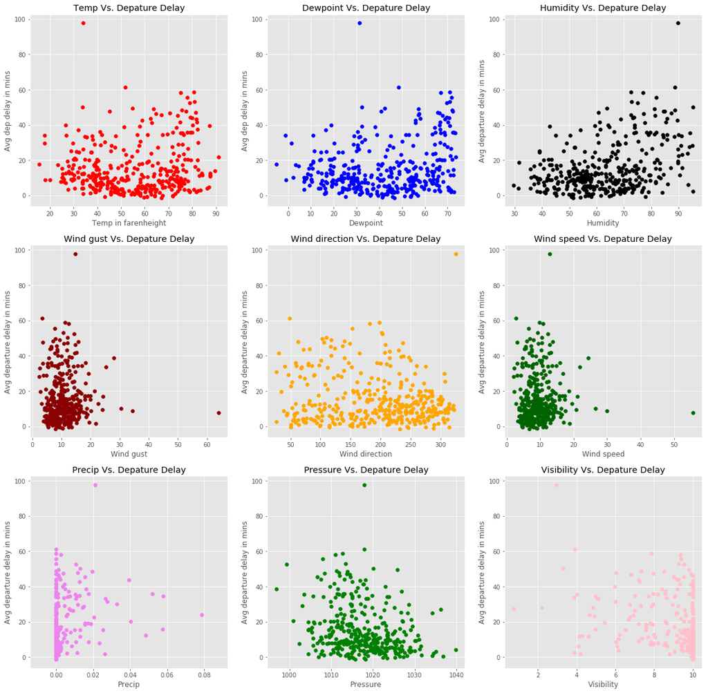

```python
rcParams['figure.figsize'] = 20, 20
fig = plt.figure()
ax1 = fig.add_subplot(331)
ax1.scatter(flights_weather['temp'], flights_weather['dep_delay'], c = 'red')
xlabel('Temp in farenheight')
ylabel('Avg dep delay in mins')
title('Temp Vs. Depature Delay')

ax2 = fig.add_subplot(332)
ax2.scatter(flights_weather['dewp'], flights_weather['dep_delay'], c = 'blue')
xlabel('Dewpoint')
ylabel('Avg dep delay in mins')
title('Dewpoint Vs. Depature Delay')

ax3 = fig.add_subplot(333)
ax3.scatter(flights_weather['humid'], flights_weather['dep_delay'], c = 'black')
xlabel('Humidity')
ylabel('Avg departure delay in mins')
title('Humidity Vs. Depature Delay')

ax4 = fig.add_subplot(334)
ax4.scatter(flights_weather['wind_gust'], flights_weather['dep_delay'], c = 'darkred')
xlabel('Wind gust')
ylabel('Avg departure delay in mins')
title('Wind gust Vs. Depature Delay')

ax5 = fig.add_subplot(335)
ax5.scatter(flights_weather['wind_dir'], flights_weather['dep_delay'], c = 'orange')
xlabel('Wind direction')
ylabel('Avg departure delay in mins')
title('Wind direction Vs. Depature Delay')

ax6 = fig.add_subplot(336)
ax6.scatter(flights_weather['wind_speed'], flights_weather['dep_delay'], c = 'darkgreen')
xlabel('Wind speed')
ylabel('Avg departure delay in mins')
title('Wind speed Vs. Depature Delay')

ax7 = fig.add_subplot(337)
ax7.scatter(flights_weather['precip'], flights_weather['dep_delay'], c = 'violet')
xlabel('Precip')
ylabel('Avg departure delay in mins')
title('Precip Vs. Depature Delay')

ax8 = fig.add_subplot(338)
ax8.scatter(flights_weather['pressure'], flights_weather['dep_delay'], c = 'green')
xlabel('Pressure')
ylabel('Avg departure delay in mins')
title('Pressure Vs. Depature Delay')

ax9 = fig.add_subplot(339)
ax9.scatter(flights_weather['visib'], flights_weather['dep_delay'], c = 'pink')
xlabel('Visibility')
ylabel('Avg departure delay in mins')
title('Visibility Vs. Depature Delay')
```

```python
mod1 = smf.ols(formula='dep_delay ~ temp', data=flights_weather).fit()
print ("Regression model summary for dep_delay and temperature:\n", mod1.params)

mod2 = smf.ols(formula='dep_delay ~ dewp', data=flights_weather).fit()
print ("\nRegression model summary for dep_delay and dewpoint:\n", mod2.params)

mod3 = smf.ols(formula='dep_delay ~ humid', data=flights_weather).fit()
print ("\nRegression model summary for dep_delay and humidity:\n", mod3.params)

mod4 = smf.ols(formula='dep_delay ~ wind_gust', data=flights_weather).fit()
print ("\nRegression model summary for dep_delay and wind_gust:\n", mod4.params)

mod5 = smf.ols(formula='dep_delay ~ wind_dir', data=flights_weather).fit()
print ("\nRegression model summary for dep_delay and wind_direction:\n", mod5.params)

mod6 = smf.ols(formula='dep_delay ~ wind_speed', data=flights_weather).fit()
print ("\nRegression model summary for dep_delay and wind_speed:\n", mod6.params)

mod7 = smf.ols(formula='dep_delay ~ precip', data=flights_weather).fit()
print ("\nRegression model summary for dep_delay and precipitation:\n", mod7.params)

mod8 = smf.ols(formula='dep_delay ~ pressure', data=flights_weather).fit()
print ("\nRegression model summary for dep_delay and pressure:\n", mod8.params)

mod9 = smf.ols(formula='dep_delay ~ visib', data=flights_weather).fit()
print ("\nRegression model summary for dep_delay and visibility:\n", mod9.params)
```

```
Regression model summary for dep_delay and temperature:
 Intercept    10.720439
temp          0.080707
dtype: float64

Regression model summary for dep_delay and dewpoint:
 Intercept    8.632177
dewp         0.157130
dtype: float64

Regression model summary for dep_delay and humidity:
 Intercept   -9.157928
humid        0.387205
dtype: float64

Regression model summary for dep_delay and wind_gust:
 Intercept    14.876774
wind_gust     0.029221
dtype: float64

Regression model summary for dep_delay and wind_direction:
 Intercept    20.182212
wind_dir     -0.025905
dtype: float64

Regression model summary for dep_delay and wind_speed:
 Intercept     14.876774
wind_speed     0.033627
dtype: float64

Regression model summary for dep_delay and precipitation:
 Intercept     13.865579
precip       447.586244
dtype: float64

Regression model summary for dep_delay and pressure:
 Intercept    520.109715
pressure      -0.496313
dtype: float64

Regression model summary for dep_delay and visibility:
 Intercept    46.574289
visib        -3.409740
dtype: float64
```

Based on the plots and regression models above, the analysis for effect of weather conditions on NYC flights in 2013 is as explained below:

1. Departure delay and temperature: With every one farenheight increase in temperature, there is 0.08 mins of increase in the departure delay.
2. Departure delay and dewpoint: With every one unit increase in dewpoint, the departure delay increases by 0.15 mins.
3. Departure delay and humidity: With every one unit increase in humidity, the departure delay increases by 0.38 mins.
4. Departure delay and wind gust: With every one unit increase in wind gust, the departure delay increase by 0.02 mins.
5. Departure delay and wind direction: With every one unit increase in wind direction, the departure delay decreases by 0.02 mins.
6. Departure delay and wind speed: With every one unit increase in wind speed, the departure delay increase by 0.03 mins.
7. Departure delay and precipitation: With every one unit increase in precipitation, the departure delay increase by 447.58 mins. This is a highest effect on the departure delay.
8. Departure delay and pressure: With every one unit increase in pressure, the departure delay decreases by 0.49 mins.
9. Departure delay and visibility: With every one unit increase in visibility, the departure delay decreases by 3.40 mins.

Based on the above graphics and regression results, we can say that weather does have an effect on flights from NYC in 2013. However, more understanding and statistical modelling is required to understand the significance level of these individual features and their impacts.